# CMPINF 2130 Summer 2021 - Week 07

Dr. Joseph P. Yurko

6/28/2021

## Load tidyverse

```r
library(tidyverse)
```

## Boxplot review

Work with the synthetic from a standard normal.

```r
set.seed(2130)

x <- rnorm(n = 5000)

xdf <- tibble::tibble(x = x)

xdf %>% glimpse()
```

```
## Rows: 5,000
## Columns: 1
## $ x <dbl> 0.48985558, 0.27478193, 0.05470678, -0.17662471, -0.92091499, -0.240~
```

Make a boxplot.

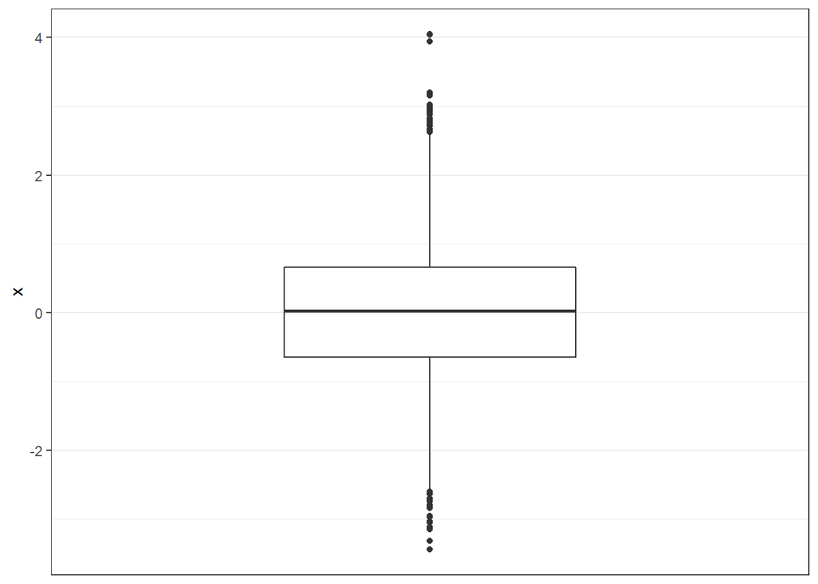

```r
xdf %>%
  ggplot(mapping = aes(y = x)) +
  geom_boxplot() +
  scale_x_discrete() +
  theme_bw()
```

Calculate the whisker length above and below the box.

```r
xdf %>%
  summarise(q25 = quantile(x, 0.25),
            q50 = median(x),
            q75 = quantile(x, 0.75)) %>%
  mutate(whisker_low = q25 - 1.5 * (q75 - q25),
         whisker_high = q75 + 1.5 * (q75 - q25))
```

```
## # A tibble: 1 x 5
##      q25    q50   q75 whisker_low whisker_high
##    <dbl>  <dbl> <dbl>       <dbl>        <dbl>
## 1 -0.645 0.0256 0.657       -2.60         2.61
```

Let’s visualize these components with `geom_linerange()`.

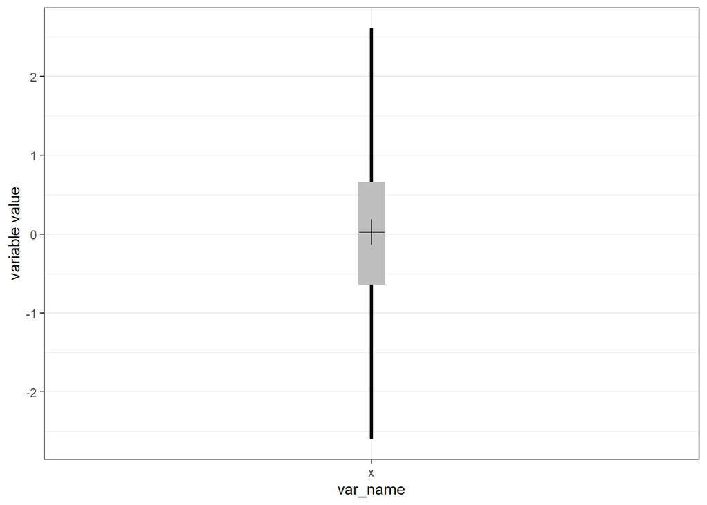

```r
xdf %>%
  summarise(q25 = quantile(x, 0.25),
            q50 = median(x),
            q75 = quantile(x, 0.75)) %>%
  mutate(whisker_low = q25 - 1.5 * (q75 - q25),
         whisker_high = q75 + 1.5 * (q75 - q25)) %>%
  mutate(var_name = 'x') %>%
  ggplot(mapping = aes(x = var_name)) +
  geom_linerange(mapping = aes(ymin = whisker_low,
                               ymax = whisker_high),
                 color = 'black', size = 1.1) +
  geom_linerange(mapping = aes(ymin = q25, ymax = q75),
                 color = 'grey', size = 9) +
  geom_point(mapping = aes(y = q50),
             shape = 3, color = 'black', size = 5.5) +
  labs(y = "variable value") +
  theme_bw()
```

Create variables for the whisker low and high points.

```r
gauss_whisker_low <- xdf %>%
  summarise(q25 = quantile(x, 0.25),
            q50 = median(x),
            q75 = quantile(x, 0.75)) %>%
  mutate(whisker_low = q25 - 1.5 * (q75 - q25),
         whisker_high = q75 + 1.5 * (q75 - q25)) %>%
  pull(whisker_low)

gauss_whisker_high <- xdf %>%
  summarise(q25 = quantile(x, 0.25),
            q50 = median(x),
            q75 = quantile(x, 0.75)) %>%
  mutate(whisker_low = q25 - 1.5 * (q75 - q25),
         whisker_high = q75 + 1.5 * (q75 - q25)) %>%
  pull(whisker_high)

(gauss_whiskers <- c(gauss_whisker_low, gauss_whisker_high))
```

```
##      25%      75%
## -2.59856  2.60977
```

Draw the manually calculated whisker endpoints on the boxplot.

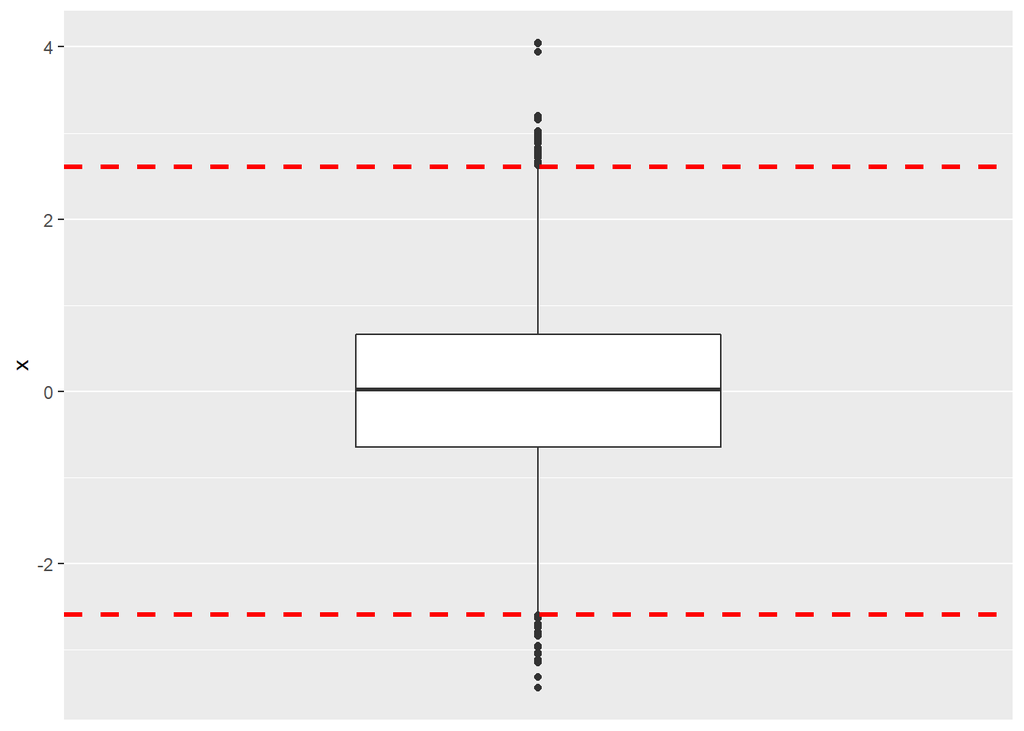

```r
xdf %>%
  ggplot(mapping = aes(y = x)) +
  geom_boxplot() +
  geom_hline(yintercept = gauss_whiskers,
             color = 'red', linetype = 'dashed', size = 1.2) +
  scale_x_discrete()
```

Why 1.5 times the IQR?

```r
xdf %>%
  mutate(xbins = cut(x,
                     breaks = c(min(x),
                                gauss_whisker_low,
                                gauss_whisker_high,
                                max(x)),
                     include.lowest = TRUE,
                     labels = c("low-outliers", "non-outliers", "high-outliers"))) %>%
  count(xbins) %>%
  mutate(percentage_value = 100 * (n / sum(n)))
```

```
## # A tibble: 3 x 3
##   xbins             n percentage_value
##   <fct>         <int>            <dbl>
## 1 low-outliers     25              0.5
## 2 non-outliers   4950             99
## 3 high-outliers    25              0.5
```

## Conditioning on a categorical

Review the `mpg` data set.

```r
mpg %>% glimpse()
```

```
## Rows: 234
## Columns: 11
## $ manufacturer <chr> "audi", "audi", "audi", "audi", "audi", "audi", "audi", "~
## $ model        <chr> "a4", "a4", "a4", "a4", "a4", "a4", "a4", "a4 quattro", "~
## $ displ        <dbl> 1.8, 1.8, 2.0, 2.0, 2.8, 2.8, 3.1, 1.8, 1.8, 2.0, 2.0, 2.~
## $ year         <int> 1999, 1999, 2008, 2008, 1999, 1999, 2008, 1999, 1999, 200~
## $ cyl          <int> 4, 4, 4, 4, 6, 6, 6, 4, 4, 4, 4, 6, 6, 6, 6, 6, 6, 8, 8, ~
## $ trans        <chr> "auto(l5)", "manual(m5)", "manual(m6)", "auto(av)", "auto~
## $ drv          <chr> "f", "f", "f", "f", "f", "f", "f", "4", "4", "4", "4", "4~
## $ cty          <int> 18, 21, 20, 21, 16, 18, 18, 18, 16, 20, 19, 15, 17, 17, 1~
## $ hwy          <int> 29, 29, 31, 30, 26, 26, 27, 26, 25, 28, 27, 25, 25, 25, 2~
## $ fl           <chr> "p", "p", "p", "p", "p", "p", "p", "p", "p", "p", "p", "p~
## $ class        <chr> "compact", "compact", "compact", "compact", "compact", "c~
```

Look at the distribution of `hwy` for each level of `drv`.

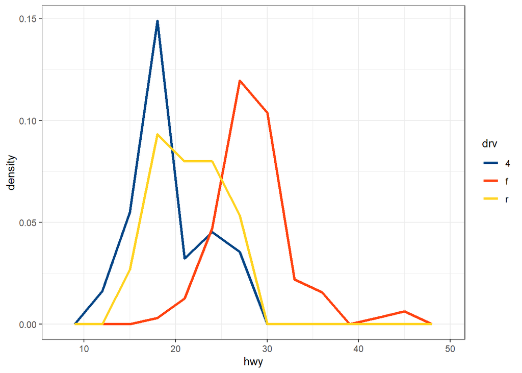

```r
mpg %>%
  ggplot(mapping = aes(x = hwy)) +
  geom_freqpoly(mapping = aes(color = drv,
                              y = stat(density)),
                size = 1.2,
                binwidth = 3) +
  ggthemes::scale_color_calc() +
  theme_bw()
```

Using density plots instead of histograms.

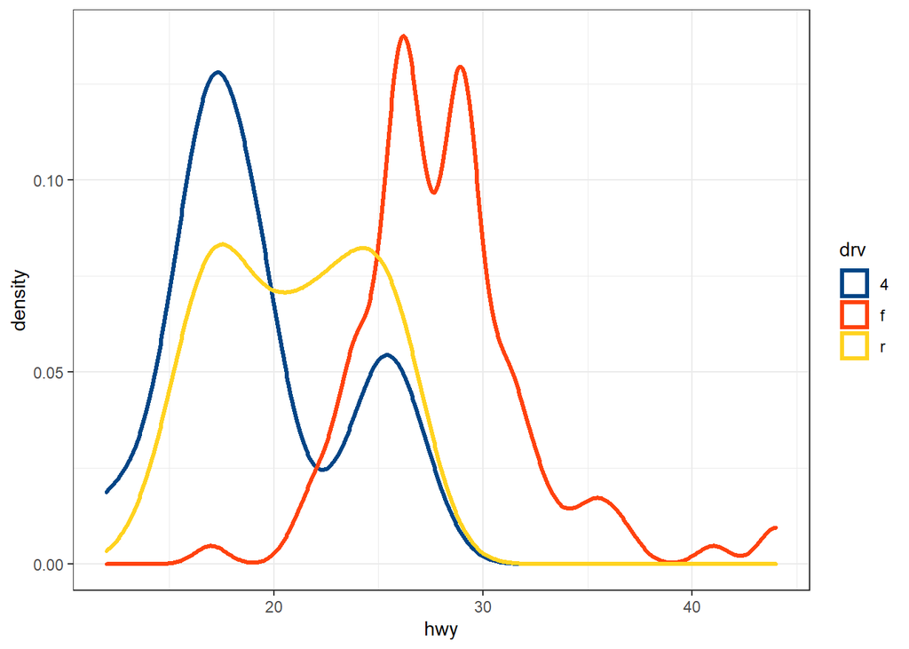

```r
mpg %>%
  ggplot(mapping = aes(x = hwy)) +
  geom_density(mapping = aes(color = drv),
               size = 1.2) +
  ggthemes::scale_color_calc() +
  theme_bw()
```

Visualize the different **conditional** distributions with a violin plot.

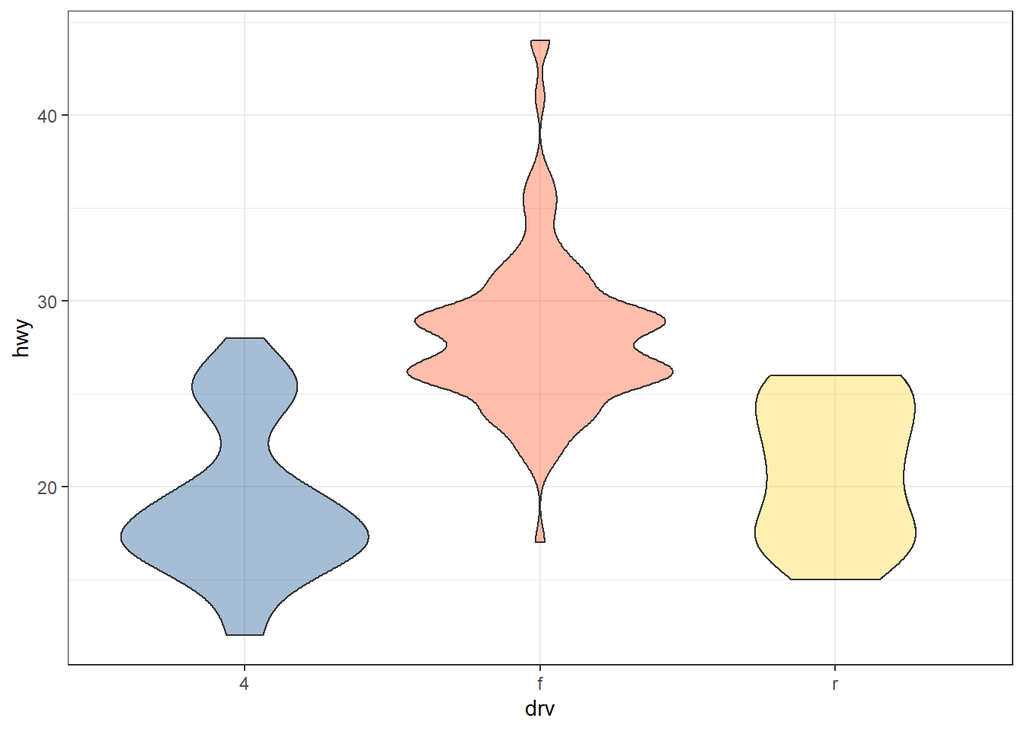

```r
mpg %>%
  ggplot(mapping = aes(x = drv, y = hwy)) +
  geom_violin(mapping = aes(fill = drv),
              alpha = 0.35) +
  ggthemes::scale_fill_calc(guide = FALSE) +
  theme_bw()
```

Downside of a violin plot is that we cannot easily see important summary statistics.

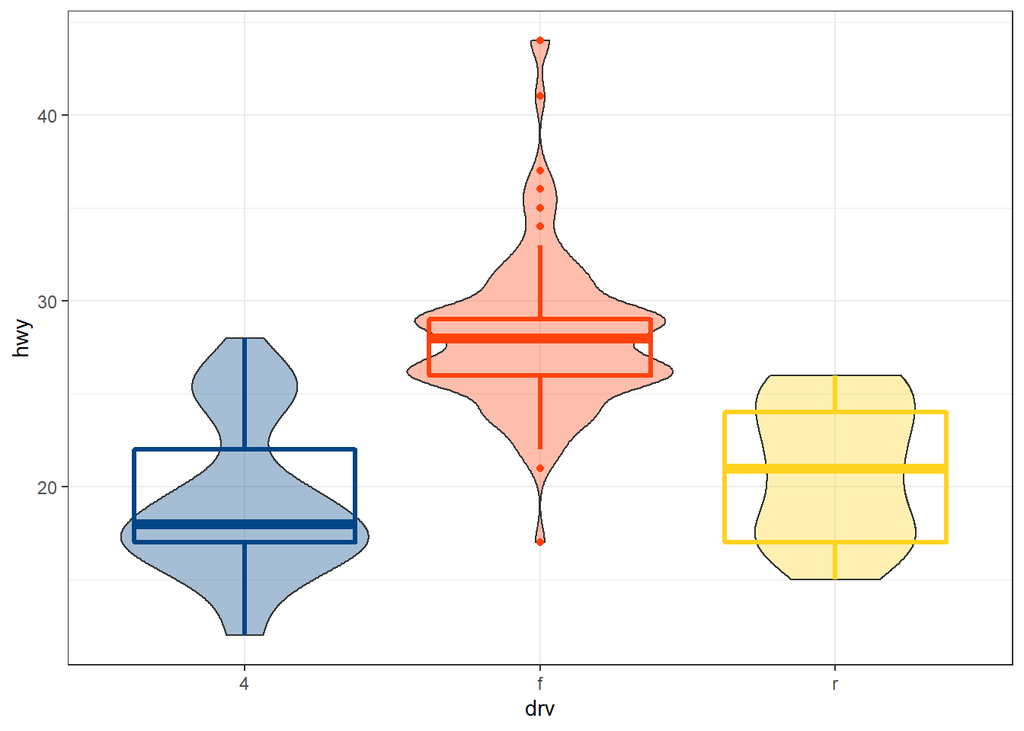

```r
mpg %>%
  ggplot(mapping = aes(x = drv, y = hwy)) +
  geom_violin(mapping = aes(fill = drv),
              alpha = 0.35) +
  geom_boxplot(mapping = aes(color = drv),
               size = 1.15,
               fill = NA) +
  ggthemes::scale_fill_calc(guide = FALSE) +
  ggthemes::scale_color_calc(guide = FALSE) +
  theme_bw()
```

Include the observations via a strip plot to get a sense if the violin density estimate is appropriate.

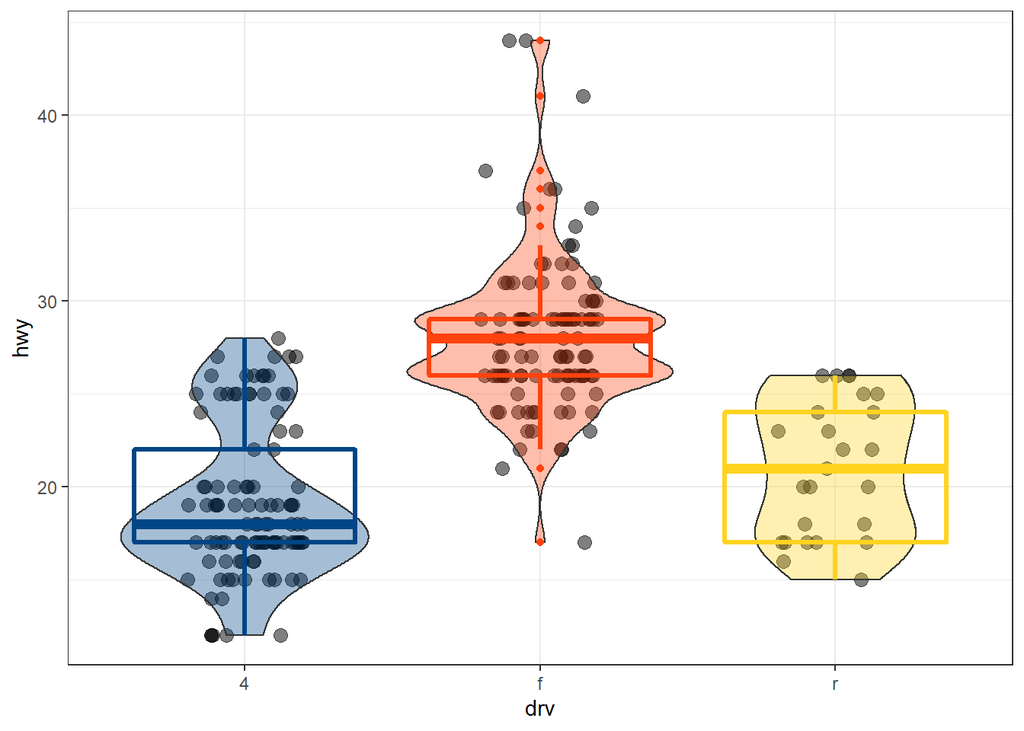

```r
mpg %>%
  ggplot(mapping = aes(x = drv, y = hwy)) +
  geom_jitter(alpha = 0.5, size = 3, height = 0, width = 0.2) +
  geom_violin(mapping = aes(fill = drv),
              alpha = 0.35) +
  geom_boxplot(mapping = aes(color = drv),
               size = 1.15,
               fill = NA) +
  ggthemes::scale_fill_calc(guide = FALSE) +
  ggthemes::scale_color_calc(guide = FALSE) +
  theme_bw()
```

### Joy plots (ridge plots)

Please download and install `ggridges` from CRAN.

```r
library(ggridges)
```

Flip the `x` and `y` aesthetics with ridge-plots compared to box and violin plots.

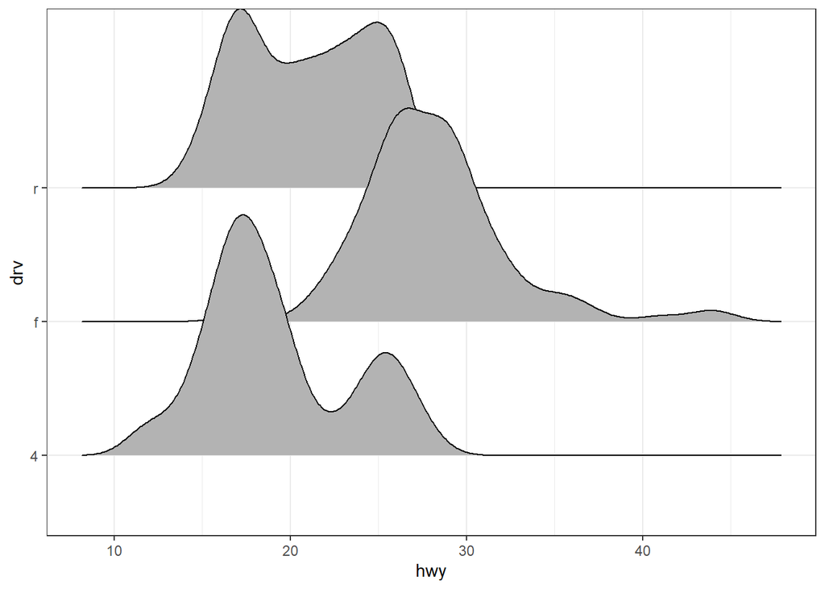

```r
mpg %>%
  ggplot(mapping = aes(x = hwy, y = drv)) +
  geom_density_ridges() +
  theme_bw()
```

We can use the `ggridges` theme.

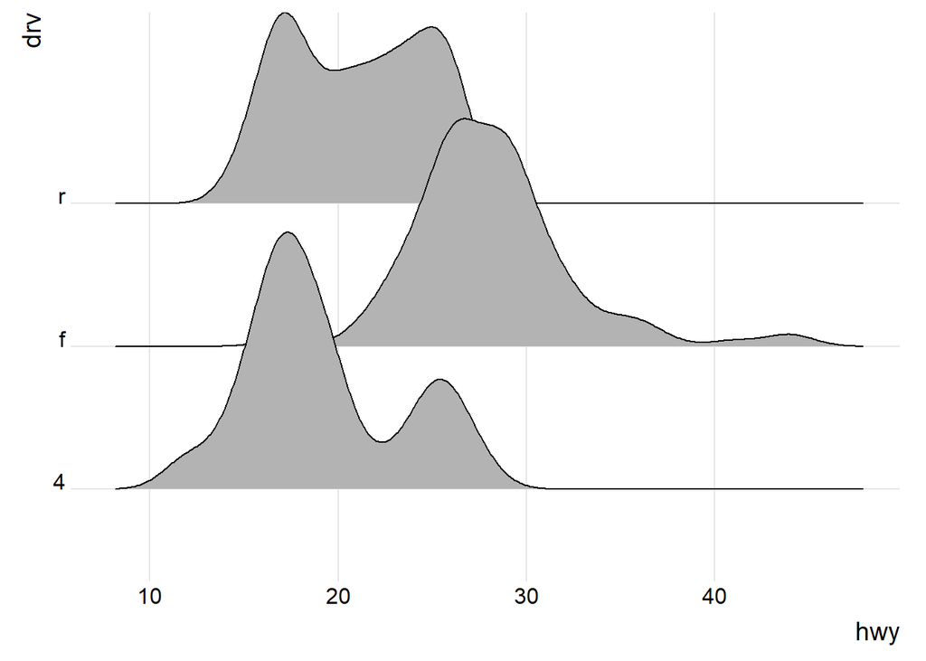

```r
mpg %>%
  ggplot(mapping = aes(x = hwy, y = drv)) +
  geom_density_ridges() +
  theme_ridges()
```

Map the `fill` to the `drv` variable.

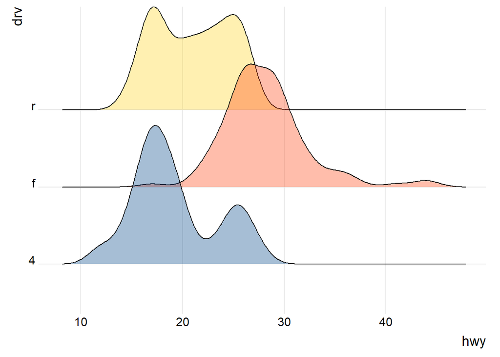

```r
mpg %>%
  ggplot(mapping = aes(x = hwy, y = drv)) +
  geom_density_ridges(mapping = aes(fill = drv),
                      alpha = 0.35) +
  ggthemes::scale_fill_calc(guide = FALSE) +
  theme_ridges()
```

Modify the vertical “height” of the densities with the `scale` argument.

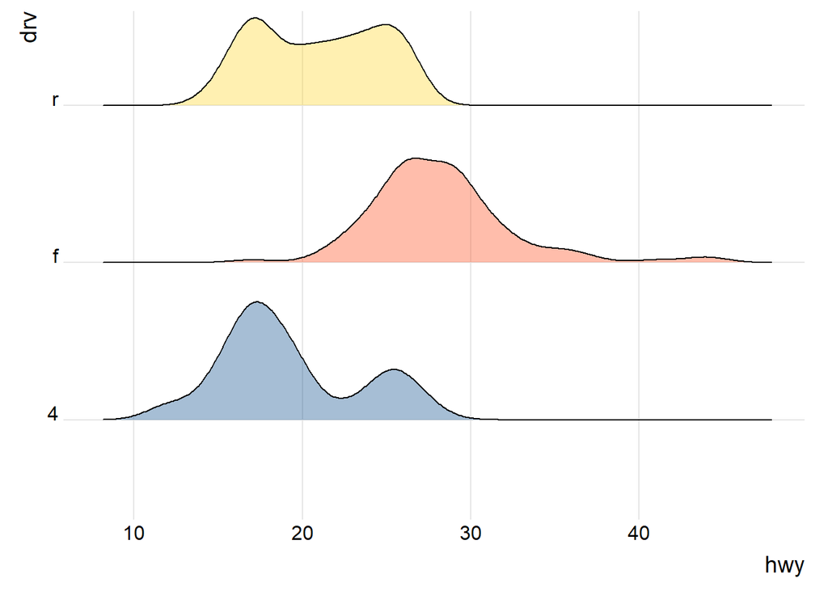

```r
mpg %>%
  ggplot(mapping = aes(x = hwy, y = drv)) +
  geom_density_ridges(mapping = aes(fill = drv),
                      alpha = 0.35,
                      scale = 0.75) +
  ggthemes::scale_fill_calc(guide = FALSE) +
  theme_ridges()
```

Modify the bandwidth or the smoothing of the density estimate.

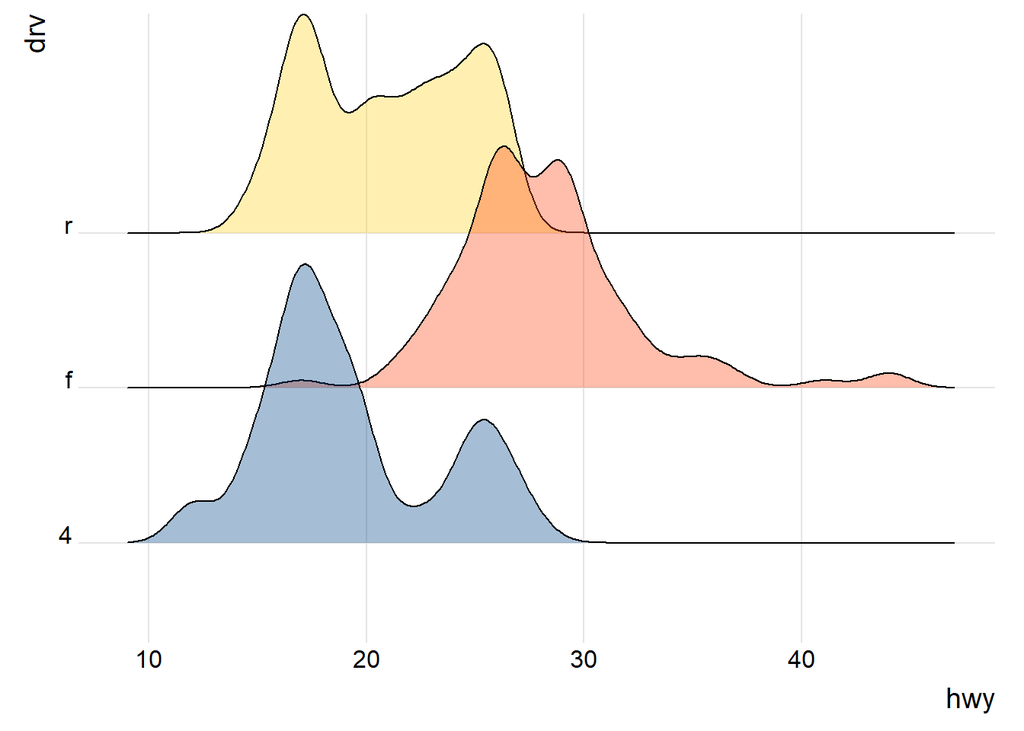

```r
mpg %>%
  ggplot(mapping = aes(x = hwy, y = drv)) +
  geom_density_ridges(mapping = aes(fill = drv),
                      alpha = 0.35,
                      bandwidth = 1.) +
  ggthemes::scale_fill_calc(guide = FALSE) +
  theme_ridges()
```

Add quantiles to the joy plot.

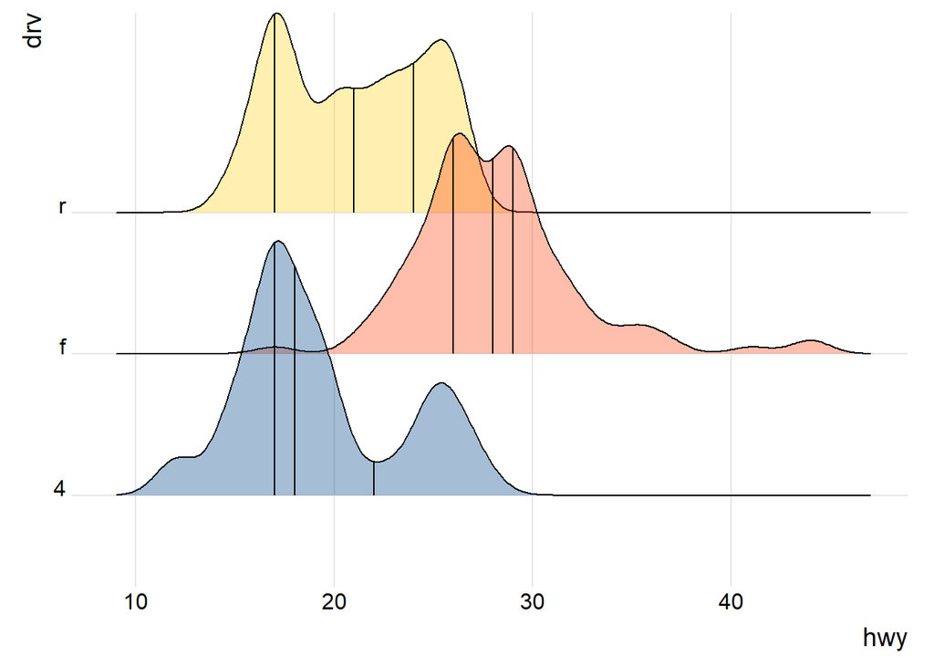

```r
mpg %>%
  ggplot(mapping = aes(x = hwy, y = drv)) +
  geom_density_ridges(mapping = aes(fill = drv),
                      alpha = 0.35,
                      bandwidth = 1.,
                      quantile_lines = TRUE) +
  ggthemes::scale_fill_calc(guide = FALSE) +
  theme_ridges()
```

Separate fill color for the quartile ranges. To make the following we have to use the underlying `stat_` function.

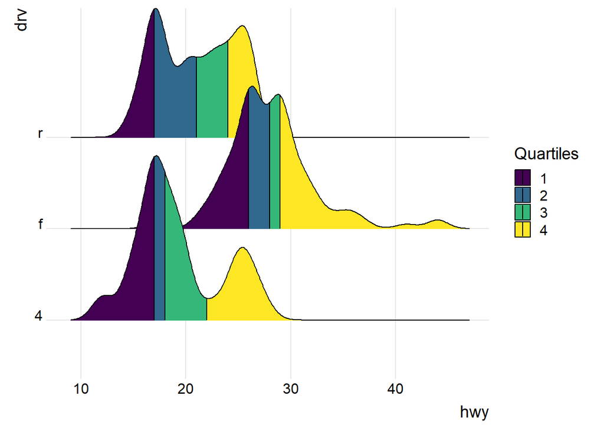

```r
mpg %>%
  ggplot(mapping = aes(x = hwy, y = drv)) +
  stat_density_ridges(geom = "density_ridges_gradient",
                      mapping = aes(fill = factor(stat(quantile))),
                      calc_ecdf = TRUE,
                      quantiles = 4,
                      quantile_lines = TRUE,
                      bandwidth = 1.) +
  scale_fill_viridis_d("Quartiles") +
  theme_ridges()
```

We can specify our own set of quantiles if we prefer. Such as the middle 80% interval.

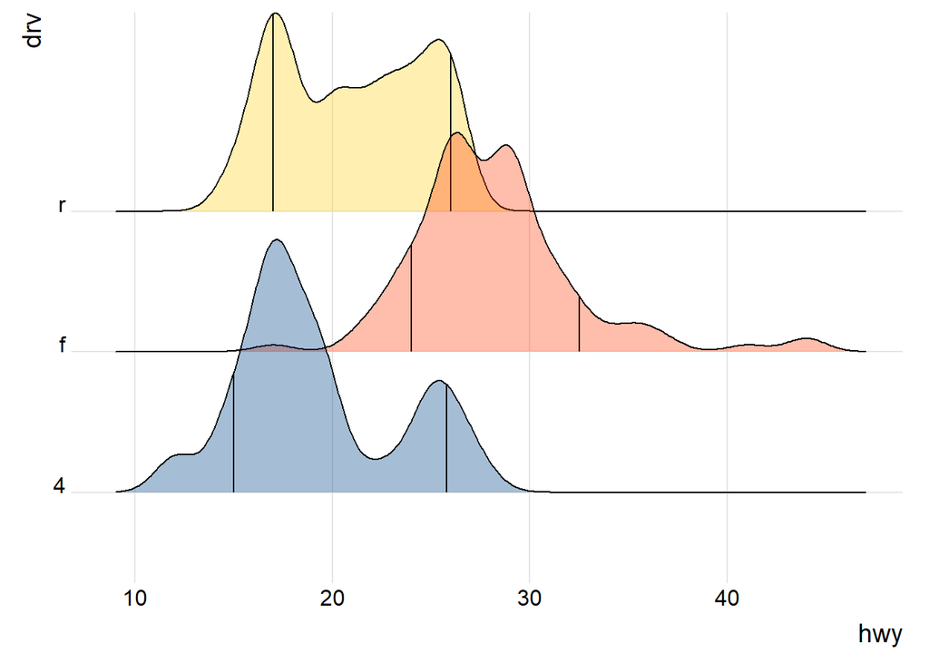

```r
mpg %>%
  ggplot(mapping = aes(x = hwy, y = drv)) +
  geom_density_ridges(mapping = aes(fill = drv),
                      alpha = 0.35,
                      bandwidth = 1.,
                      quantile_lines = TRUE,
                      quantiles = c(0.1, 0.9)) +
  ggthemes::scale_fill_calc(guide = FALSE) +
  theme_ridges()
```

Fill in the 3 intervals with a manual color scale.

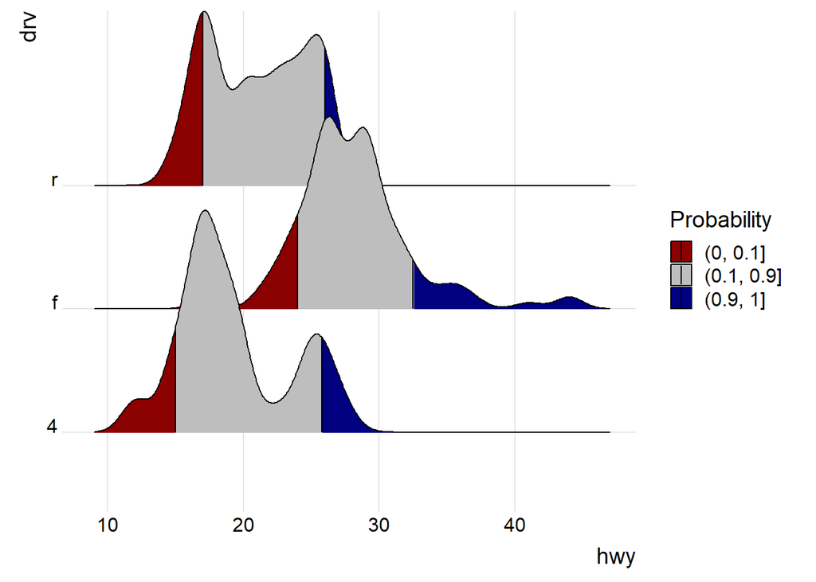

```r
mpg %>%
  ggplot(mapping = aes(x = hwy, y = drv)) +
  stat_density_ridges(geom = "density_ridges_gradient",
                      mapping = aes(fill = factor(stat(quantile))),
                      calc_ecdf = TRUE,
                      quantile_lines = TRUE,
                      quantiles = c(0.1, 0.9),
                      bandwidth = 1.) +
  scale_fill_manual("Probability",
                    values = c("darkred", "grey", "navyblue"),
                    labels = c("(0, 0.1]", "(0.1, 0.9]", "(0.9, 1]")) +
  theme_ridges()
```

To understand if the density is representative of the underlying data, let’s include the measruements directly on the graphic.

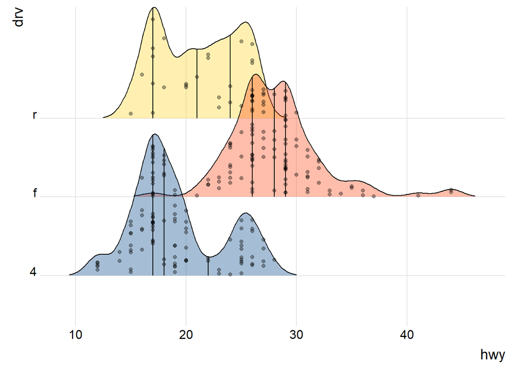

```r
mpg %>%
  ggplot(mapping = aes(x = hwy, y = drv)) +
  geom_density_ridges(mapping = aes(fill = drv),
                      alpha = 0.35,
                      bandwidth = 1.,
                      quantile_lines = TRUE,
                      jittered_points = TRUE,
                      rel_min_height = 0.005) +
  ggthemes::scale_fill_calc(guide = FALSE) +
  theme_ridges()
```

We can position the markers below the density plot to create the **raincloud** plot.

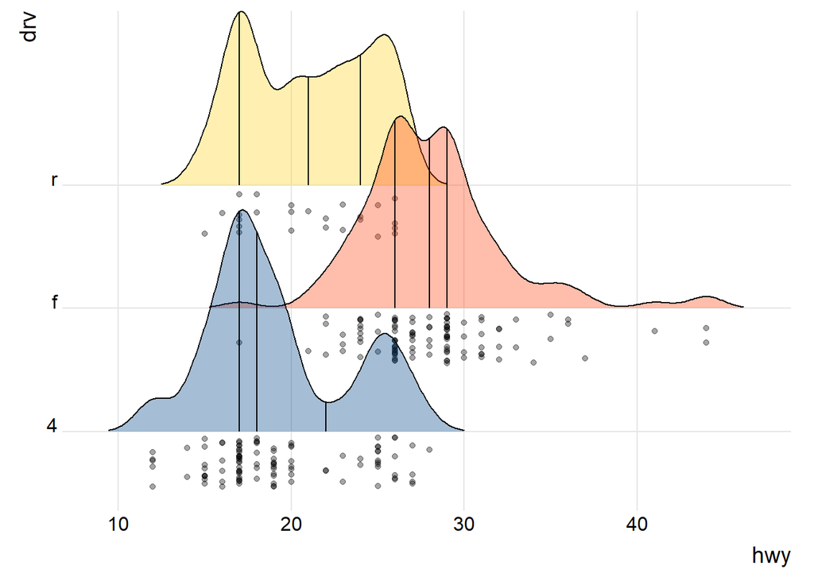

```r
mpg %>%
  ggplot(mapping = aes(x = hwy, y = drv)) +
  geom_density_ridges(mapping = aes(fill = drv),
                      alpha = 0.35,
                      bandwidth = 1.,
                      quantile_lines = TRUE,
                      jittered_points = TRUE,
                      rel_min_height = 0.005,
                      position = 'raincloud') +
  ggthemes::scale_fill_calc(guide = FALSE) +
  theme_ridges()
```

We can modify the points to look more like a rug plot to further help identify high density intervals.

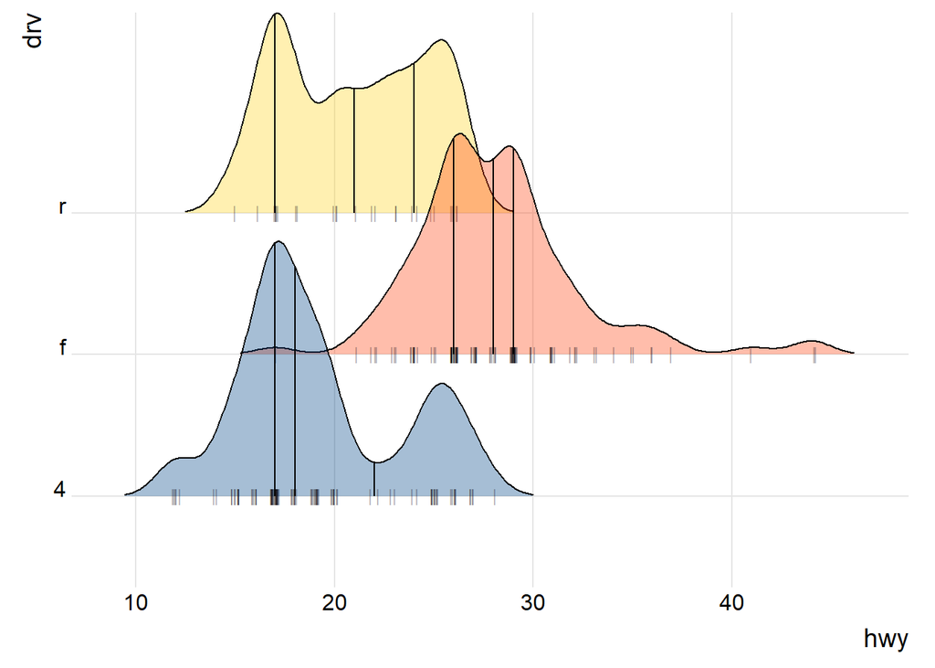

```r
mpg %>%
  ggplot(mapping = aes(x = hwy, y = drv)) +
  geom_density_ridges(mapping = aes(fill = drv),
                      alpha = 0.35,
                      bandwidth = 1.,
                      quantile_lines = TRUE,
                      jittered_points = TRUE,
                      rel_min_height = 0.005,
                      position = position_points_jitter(width = 0.2, height = 0),
                      point_shape = "|", point_alpha = 0.3, point_size = 3) +
  ggthemes::scale_fill_calc(guide = FALSE) +
  theme_ridges()
```

Joy plots are particularly useful when you are comparing how a distribution “evolves” over time.

```r
lincoln_weather %>% glimpse()
```

```
## Rows: 366
## Columns: 24
## $ CST                            <chr> "2016-1-1", "2016-1-2", "2016-1-3", "20~
## $ `Max Temperature [F]`          <int> 37, 41, 37, 30, 38, 34, 33, 28, 22, 31,~
## $ `Mean Temperature [F]`         <int> 24, 23, 23, 17, 29, 33, 30, 25, 9, 11, ~
## $ `Min Temperature [F]`          <int> 11, 5, 8, 4, 19, 32, 27, 22, -4, -9, 18~
## $ `Max Dew Point [F]`            <int> 19, 22, 23, 24, 29, 33, 32, 25, 17, 20,~
## $ `Mean Dew Point [F]`           <int> 13, 14, 15, 13, 25, 32, 30, 22, 4, 5, 2~
## $ `Min Dewpoint [F]`             <int> 8, 4, 8, 2, 19, 29, 25, 18, -8, -13, 16~
## $ `Max Humidity`                 <int> 88, 100, 92, 92, 96, 100, 100, 92, 87, ~
## $ `Mean Humidity`                <int> 68, 72, 73, 82, 83, 91, 96, 85, 77, 75,~
## $ `Min Humidity`                 <int> 47, 44, 54, 72, 70, 82, 92, 78, 67, 63,~
## $ `Max Sea Level Pressure [In]`  <dbl> 30.50, 30.35, 30.50, 30.50, 30.20, 29.9~
## $ `Mean Sea Level Pressure [In]` <dbl> 30.39, 30.30, 30.42, 30.39, 30.06, 29.9~
## $ `Min Sea Level Pressure [In]`  <dbl> 30.30, 30.22, 30.32, 30.18, 29.99, 29.8~
## $ `Max Visibility [Miles]`       <int> 10, 10, 10, 10, 10, 10, 9, 10, 10, 10, ~
## $ `Mean Visibility [Miles]`      <int> 10, 10, 10, 9, 8, 4, 3, 6, 9, 10, 10, 1~
## $ `Min Visibility [Miles]`       <int> 10, 10, 10, 6, 5, 0, 0, 2, 5, 10, 10, 5~
## $ `Max Wind Speed [MPH]`         <int> 20, 15, 13, 17, 22, 16, 16, 25, 25, 10,~
## $ `Mean Wind Speed[MPH]`         <int> 9, 6, 5, 7, 13, 7, 7, 16, 14, 5, 14, 6,~
## $ `Max Gust Speed [MPH]`         <int> 23, 18, 14, 23, 28, 21, 21, 32, 28, 12,~
## $ `Precipitation [In]`           <chr> "0", "0", "0", "0", "0", "T", "0", "0",~
## $ CloudCover                     <int> 0, 0, 0, 1, 4, 8, 8, 8, 5, 0, 7, 5, 0, ~
## $ Events                         <chr> NA, NA, NA, NA, NA, "Fog", "Fog", "Snow~
## $ `WindDir [Degrees]`            <int> 280, 312, 330, 155, 178, 167, 7, 338, 3~
## $ Month                          <fct> January, January, January, January, Jan~
```

Look how the average or mean temperature per day distribution evolves over the months.

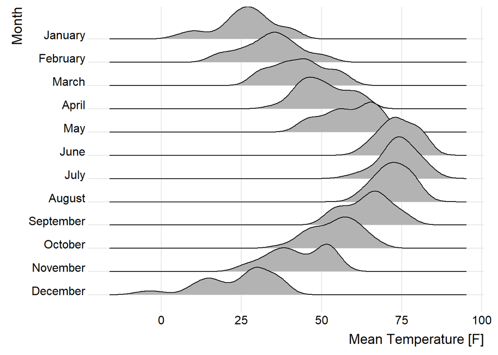

```r
lincoln_weather %>%
  ggplot(mapping = aes(x = `Mean Temperature [F]`, y = Month)) +
  geom_density_ridges() +
  theme_ridges()
```

Modifying the relative min height can help with the visual sometimes.

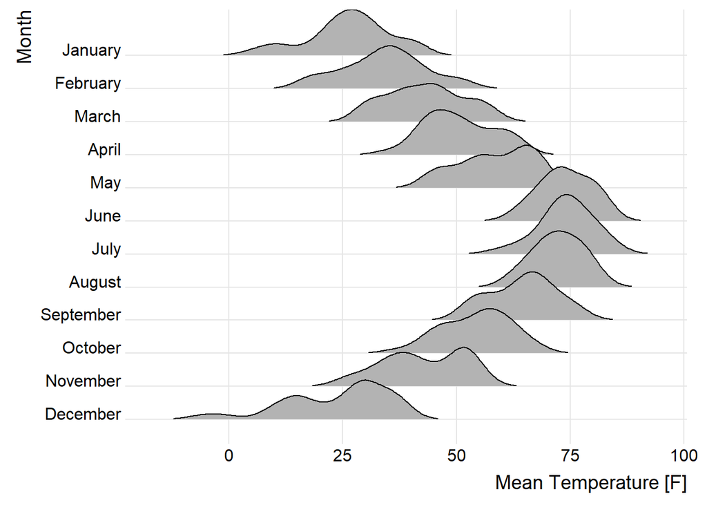

```r
lincoln_weather %>%
  ggplot(mapping = aes(x = `Mean Temperature [F]`, y = Month)) +
  geom_density_ridges(rel_min_height = 0.01) +
  theme_ridges()
```

Modify the height to help with the visual.

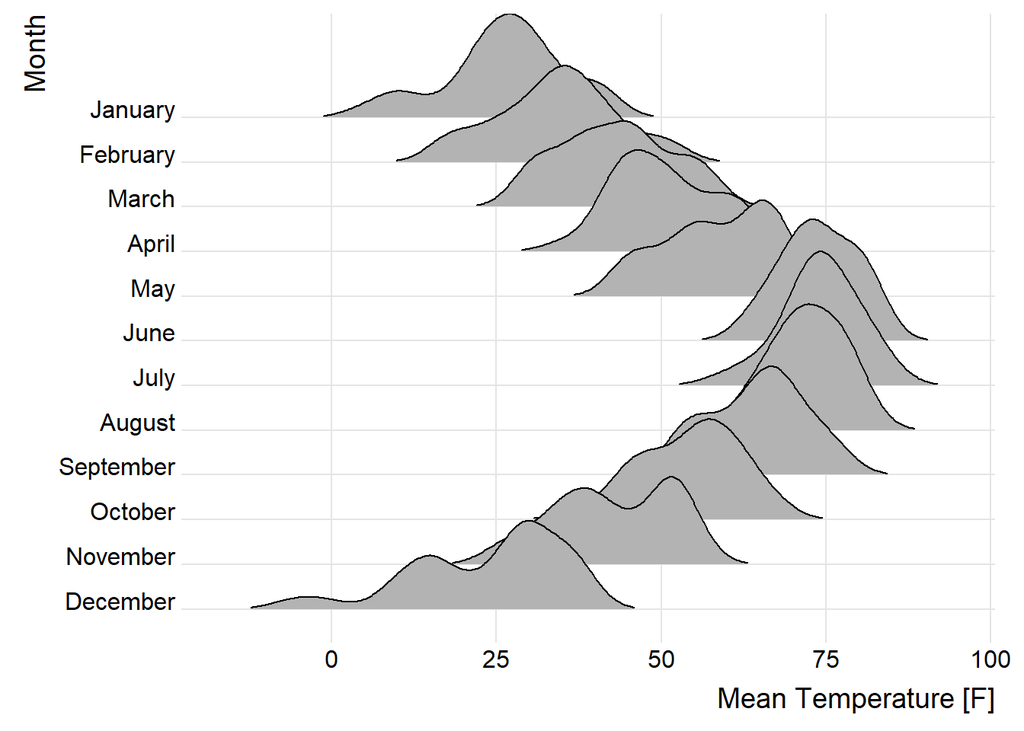

```r
lincoln_weather %>%
  ggplot(mapping = aes(x = `Mean Temperature [F]`, y = Month)) +
  geom_density_ridges(rel_min_height = 0.01, scale=3) +
  theme_ridges()
```

Fill the ridge area based on the value on the `x` axis.

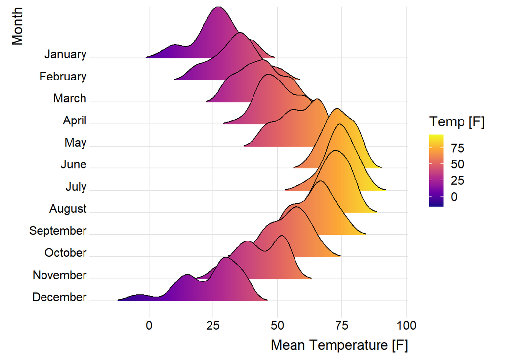

```r
lincoln_weather %>%
  ggplot(mapping = aes(x = `Mean Temperature [F]`, y = Month)) +
  geom_density_ridges_gradient(rel_min_height = 0.01, scale=3,
                               mapping = aes(fill = stat(x))) +
  scale_fill_viridis_c("Temp [F]", option = 'plasma') +
  theme_ridges()
```

Raincloud for the temperatures.

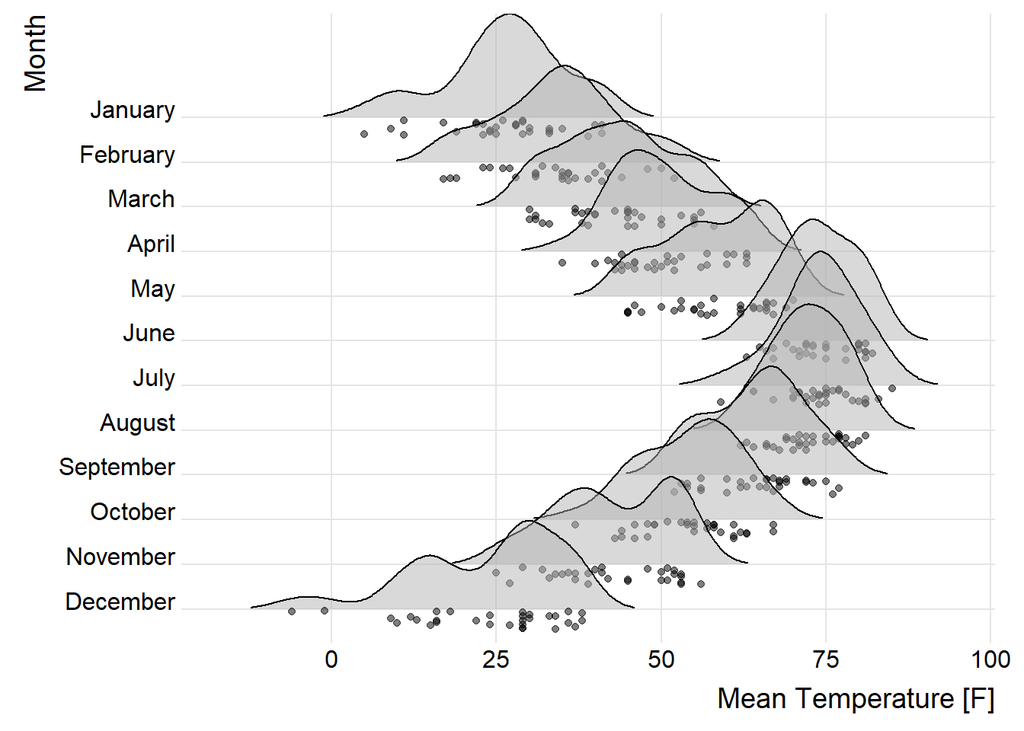

```r
lincoln_weather %>%
  ggplot(mapping = aes(x = `Mean Temperature [F]`, y = Month)) +
  geom_density_ridges(rel_min_height = 0.01, scale=3,
                      jittered_points = TRUE,
                      position = 'raincloud',
                      alpha = 0.5) +
  theme_ridges()
```

Please see the documentation [ggridges](https://wilkelab.org/ggridges/index.html) and the [vignette](https://cran.r-project.org/web/packages/ggridges/vignettes/gallery.html)

## Comparing averages across groups

Look at the distribution of `hwy` per `drv`.

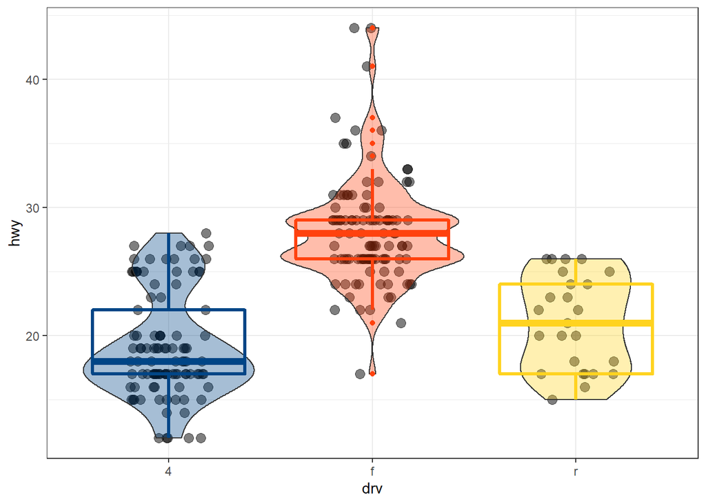

```r
mpg %>%
  ggplot(mapping = aes(x = drv, y = hwy)) +
  geom_jitter(alpha = 0.5, size = 3, height = 0, width = 0.2) +
  geom_violin(mapping = aes(fill = drv),
              alpha = 0.35) +
  geom_boxplot(mapping = aes(color = drv),
               size = 1.15,
               fill = NA) +
  ggthemes::scale_fill_calc(guide = FALSE) +
  ggthemes::scale_color_calc(guide = FALSE) +
  theme_bw()
```

Calculate the group-level averages.

```r
mpg %>%
  group_by(drv) %>%
  summarise(avg_hwy = mean(hwy))
```

```
## # A tibble: 3 x 2
##   drv   avg_hwy
##   <chr>   <dbl>
## 1 4        19.2
## 2 f        28.2
## 3 r        21
```

We can override the default or **inherited** data argument from the parent `ggplot()` call. Each geometric layer can have its own data set.

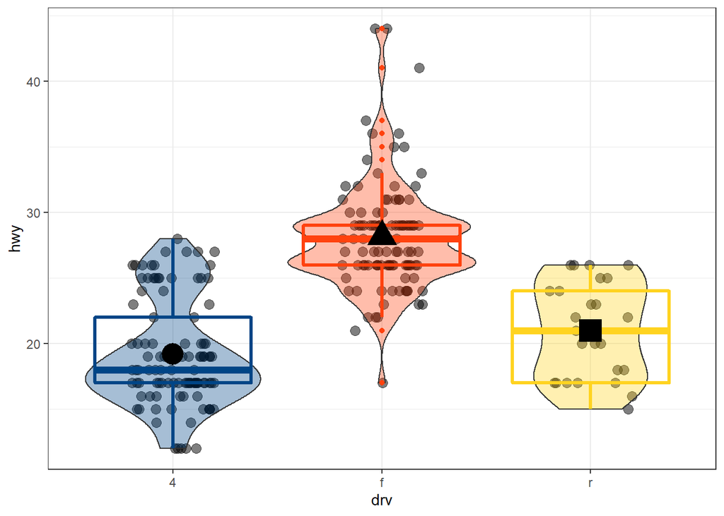

```r
mpg %>%
  ggplot(mapping = aes(x = drv, y = hwy)) +
  geom_jitter(alpha = 0.5, size = 3, height = 0, width = 0.2) +
  geom_violin(mapping = aes(fill = drv),
              alpha = 0.35) +
  geom_boxplot(mapping = aes(color = drv),
               size = 1.15,
               fill = NA) +
  # override the data argument
  geom_point(data = mpg %>%
               group_by(drv) %>%
               summarise(avg_hwy = mean(hwy)),
             mapping = aes(y = avg_hwy,
                           shape = drv),
             size = 7) +
  ggthemes::scale_fill_calc(guide = FALSE) +
  ggthemes::scale_color_calc(guide = FALSE) +
  scale_shape_discrete(guide = FALSE) +
  theme_bw()
```

We can work with the original data and instruct ggplot2 to summarize via `stat_summary()`.

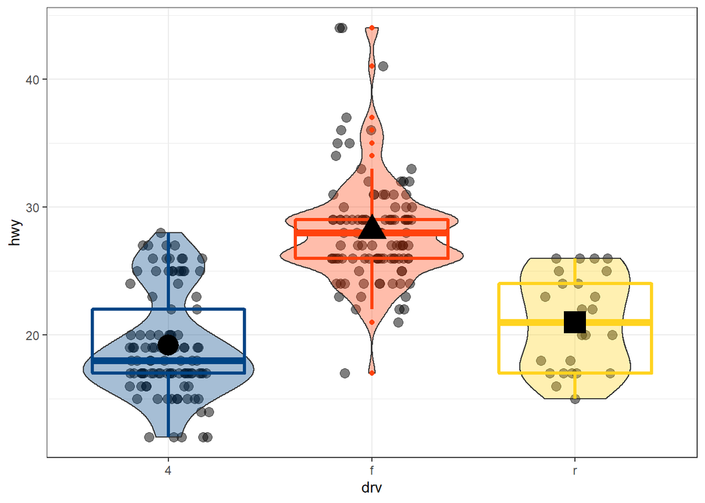

```r
mpg %>%
  ggplot(mapping = aes(x = drv, y = hwy)) +
  geom_jitter(alpha = 0.5, size = 3, height = 0, width = 0.2) +
  geom_violin(mapping = aes(fill = drv),
              alpha = 0.35) +
  geom_boxplot(mapping = aes(color = drv),
               size = 1.15,
               fill = NA) +
  # summarize the data via stat_summary()
  stat_summary(geom = 'point',
               fun = 'mean',
               mapping = aes(shape = drv),
               size = 7) +
  ggthemes::scale_fill_calc(guide = FALSE) +
  ggthemes::scale_color_calc(guide = FALSE) +
  scale_shape_discrete(guide = FALSE) +
  theme_bw()
```

When showing the group-level averages sometimes it’s useful to not show the individual observations.

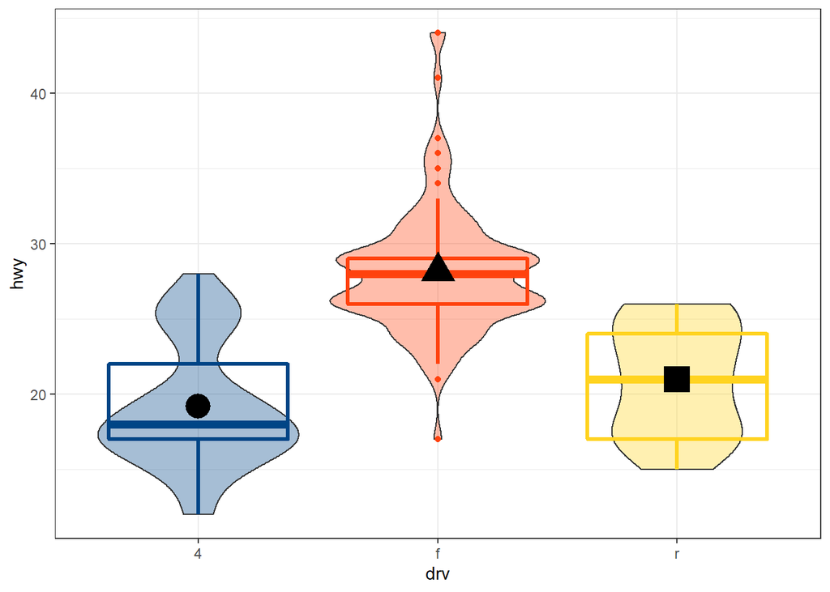

```r
mpg %>%
  ggplot(mapping = aes(x = drv, y = hwy)) +
  # geom_jitter(alpha = 0.5, size = 3, height = 0, width = 0.2) +
  geom_violin(mapping = aes(fill = drv),
              alpha = 0.35) +
  geom_boxplot(mapping = aes(color = drv),
               size = 1.15,
               fill = NA) +
  # summarize the data via stat_summary()
  stat_summary(geom = 'point',
               fun = 'mean',
               mapping = aes(shape = drv),
               size = 7) +
  ggthemes::scale_fill_calc(guide = FALSE) +
  ggthemes::scale_color_calc(guide = FALSE) +
  scale_shape_discrete(guide = FALSE) +
  theme_bw()
```

But how confident are we in the average?

What is the **standard error** on the sample average?

$$se = \sqrt{ \frac{Var(x)}{N} }$$

Calculate the standard error on the average and calculate the 95% confidence interval on the average.

```r
mpg %>%
  group_by(drv) %>%
  summarise(num_rows = n(),
            avg_hwy = mean(hwy),
            sd_hwy = sd(hwy)) %>%
  ungroup() %>%
  mutate(avg_hwy_se = sd_hwy / sqrt(num_rows)) %>%
  mutate(avg_hwy_lwr = avg_hwy - 2 * avg_hwy_se,
         avg_hwy_upr = avg_hwy + 2 * avg_hwy_se) %>%
  select(drv, avg_hwy_lwr, avg_hwy, avg_hwy_upr)
```

```
## # A tibble: 3 x 4
##   drv   avg_hwy_lwr avg_hwy avg_hwy_upr
##   <chr>       <dbl>   <dbl>       <dbl>
## 1 4            18.4    19.2        20.0
## 2 f            27.3    28.2        29.0
## 3 r            19.5    21          22.5
```

We can visualize the sample average and the confidence interval on the sample average with the `geom_pointrange()`.

```r
drv_group_summary <- mpg %>%
  group_by(drv) %>%
  summarise(num_rows = n(),
            avg_hwy = mean(hwy),
            sd_hwy = sd(hwy)) %>%
  ungroup() %>%
  mutate(avg_hwy_se = sd_hwy / sqrt(num_rows)) %>%
  mutate(avg_hwy_lwr = avg_hwy - 2 * avg_hwy_se,
         avg_hwy_upr = avg_hwy + 2 * avg_hwy_se)
```

Let’s override the default data argument and manually show the `geom_pointrange()`.

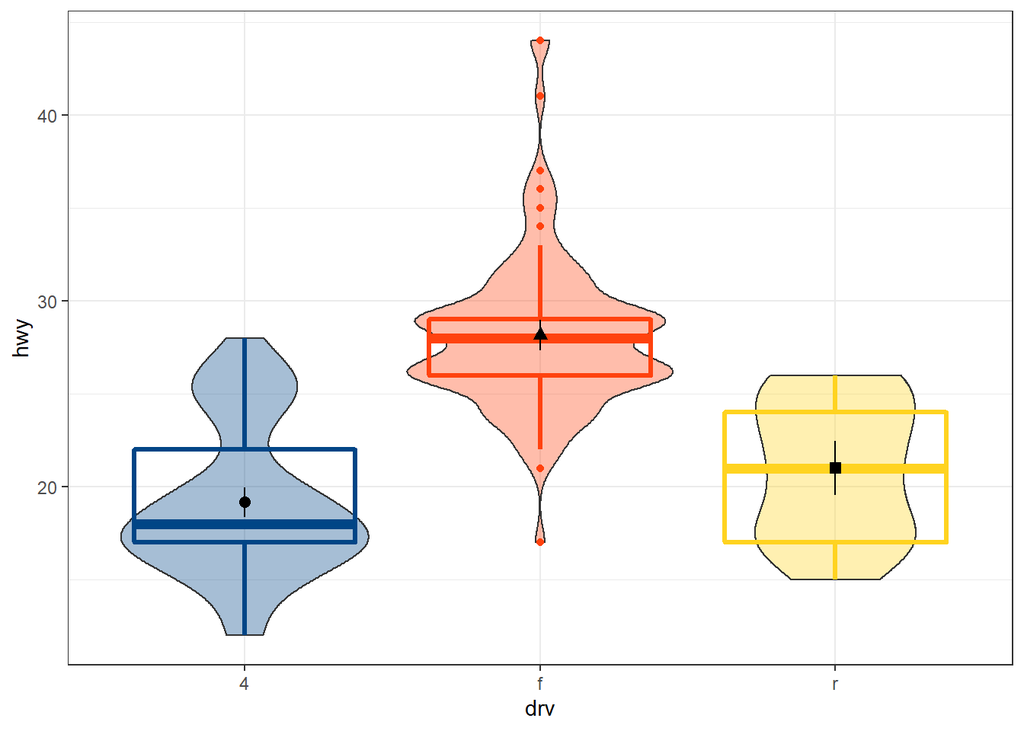

```r
mpg %>%
  ggplot(mapping = aes(x = drv, y = hwy)) +
  # geom_jitter(alpha = 0.5, size = 3, height = 0, width = 0.2) +
  geom_violin(mapping = aes(fill = drv),
              alpha = 0.35) +
  geom_boxplot(mapping = aes(color = drv),
               size = 1.15,
               fill = NA) +
  # manually override the data argument
  geom_pointrange(data = drv_group_summary,
                  mapping = aes(y = avg_hwy,
                                ymin = avg_hwy_lwr,
                                ymax = avg_hwy_upr,
                                shape = drv),
                  color = 'black') +
  ggthemes::scale_fill_calc(guide = FALSE) +
  ggthemes::scale_color_calc(guide = FALSE) +
  scale_shape_discrete(guide = FALSE) +
  theme_bw()
```

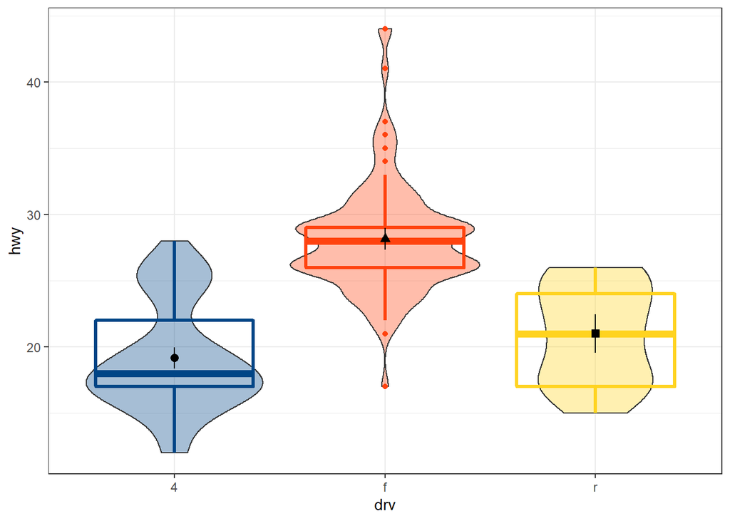

```r
mpg %>%
  ggplot(mapping = aes(x = drv, y = hwy)) +
  # geom_jitter(alpha = 0.5, size = 3, height = 0, width = 0.2) +
  geom_violin(mapping = aes(fill = drv),
              alpha = 0.35) +
  geom_boxplot(mapping = aes(color = drv),
               size = 1.15,
               fill = NA) +
  stat_summary(fun.data = 'mean_se',
               mapping = aes(shape = drv),
               fun.args = list(mult = 2)) +
  ggthemes::scale_fill_calc(guide = FALSE) +
  ggthemes::scale_color_calc(guide = FALSE) +
  scale_shape_discrete(guide = FALSE) +
  theme_bw()
```

We can use `stat_summary()` to summarize a data set however we wish.

```r
my_quantile_0.1 <- function(x, p=0.1){quantile(x, p)}

my_quantile_0.25 <- function(x, p=0.25){quantile(x, p)}

my_quantile_0.75 <- function(x, p=0.75){quantile(x, p)}

my_quantile_0.9 <- function(x, p=0.9){quantile(x, p)}
```